# Assignment 2: Hand Gesture Recognition [50 Pt]

This assignment will be completed in two parts. In Part A you will gain experience gathering your own data set (specifically images of hand gestures), and understand the challenges involved in the data cleaning process. In Part B you will train a convolutional neural network to make classifications on different hand gestures. By the end of this assignment, you should be able to:

1. Generate and preprocess your own data
2. Load and split data for training, validation and testing
3. Train a Convolutional Neural Network
4. Apply transfer learning to improve your model

Note that for this assignment we will not be providing you with any starter code. You should be able to take the sample code provided in the preparation sample code, previous assignment, and lectures and modify it accordingly to complete the tasks outlined below.

*This assignment is based on an assignment developed by Prof. Lisa Zhang.*

### What to submit

**Submission for Part A:**  
Submit a zip file containing your images. Three images each of American Sign Language gestures for letters A - I (total of 27 images). You will be required to clean the images before submitting them. Details are provided under Part A of the handout.

Individual image file names should follow the convention of student-number_Alphabet_file-number.jpg (e.g. 100343434_A_1.jpg).

**Submission for Part B:**  
Submit an HTML file containing all your code, outputs, and write-up from parts A and B. You can produce a HTML file directly from Google Colab. The Colab instructions are provided at the end of this document. For Part B5(iii), submit a single .csv file following the specified naming and formatting instructions.

**Do not submit any other files produced by your code.**

Include a link to your colab file in your submission.

Please use Google Colab to complete this assignment. If you want to use Jupyter Notebook, please complete the assignment and upload your Jupyter Notebook file to Google Colab for submission.

## Colab Link

Include a link to your colab file here and ensure the file can be accessed by the our teaching team.

```python
# TO BE COMPLETED
https://colab.research.google.com/drive/1o9WxhEIRPnXpo0Uhr0pXHWI3aGBy-zH2#scrollTo=TeX7gWbmMdqh
```

# Part A. Data Collection [5pt]

So far, we have worked with data sets that have been collected, cleaned, and curated by machine learning researchers and practitioners. Datasets like MNIST and CIFAR are often used as toy examples, both by students and by researchers testing new machine learning models.

In the real world, getting a clean data set is never that easy. More than half the work in applying machine learning is finding, gathering, cleaning, and formatting your data set.

The purpose of this assignment is to help you gain experience gathering your own data set, and understand the challenges involved in the data cleaning process.

### American Sign Language

American Sign Language (ASL) is a complete, complex language that employs signs made by moving the hands combined with facial expressions and postures of the body. It is the primary language of many North Americans who are deaf and is one of several communication options used by people who are deaf or hard-of-hearing.

**[IMAGE REMOVED: attachment:image.png]**

### Generating Data

We will produce the images required to assess our models by ourselves. You are required to collect, clean and submit three images each of Americal Sign Language gestures for letters A - I (total of 27 images) Steps involved in data collection

1. Familiarize yourself with American Sign Language gestures for letters from A - I (9 letters).
2. Take three pictures at slightly different orientation for each letter gesture using your mobile phone.
- Ensure adequate lighting while you are capturing the images.
- Use a white wall as your background.
- Use your right hand to create gestures (for consistency).
- Keep your right hand fairly apart from your body and any other obstructions.
- Avoid having shadows on parts of your hand.
3. Transfer the images to your laptop for cleaning.

### Cleaning Data

To simplify the machine learning the task, we will standardize the training images. We will make sure that all our images are of the same size (224 x 224 pixels RGB), and have the hand in the center of the cropped regions.

You may use the following applications to crop and resize your images:

**Mac**

- Use Preview: – Holding down CMD + Shift will keep a square aspect ratio while selecting the hand area. – Resize to 224x224 pixels.

**Windows 10**

- Use Photos app to edit and crop the image and keep the aspect ratio a square.
- Use Paint to resize the image to the final image size of 224x224 pixels.

**Linux**

- You can use GIMP, imagemagick, or other tools of your choosing. You may also use online tools such as http://picresize.com All the above steps are illustrative only. You need not follow these steps but following these will ensure that you produce a good quality dataset. You will be judged based on the quality of the images alone. Please do not edit your photos in any other way. You should not need to change the aspect ratio of your image. You also should not digitally remove the background or shadows—instead, take photos with a white background and minimal shadows.

### Accepted Images

Images will be accepted and graded based on the criteria below

1. The final image should be size 224x224 pixels (RGB).
2. The file format should be a .jpg file.
3. The hand should be approximately centered on the frame.
4. The hand should not be obscured or cut off.
5. The photos follows the ASL gestures posted earlier.
6. The photos were not edited in any other way (e.g. no electronic removal of shadows or background).

### Submission

Submit a zip file containing your images. There should be a total of 27 images (3 for each category)

1. Individual image file names should follow the convention of student-number_Alphabet_file-number.jpg (e.g. 100343434_A_1.jpg)
2. Zip all the images together and name it with the following convention: last-name_student-number.zip (e.g. last-name_100343434.zip).
3. Submit the zipped folder.

[figure not shown]

# Part B. Building a CNN [45pt]

For this assignment, we are not going to give you any starter code. You will be writing a convolutional neural network from scratch. You are welcome to modify and combine code provided previously in the course (assignments, preparation code, lectures, etc.). You can also write your own code.

You may use the PyTorch documentation freely. You might also find online tutorials helpful. However, all code that you submit must be be your own. You cannot take a completed assignment and claim it as your own.

Make sure that your code is vectorized, and does not contain obvious inefficiencies (for example, unecessary for loops, or unnecessary calls to unsqueeze()). Ensure enough comments are included in the code so that your TA can understand what you are doing. It is your responsibility to show that you understand what you write.

**This is much more challenging and time-consuming than the previous assignments.** Make sure that you give yourself plenty of time by starting early.

**Using the GPU Accelerator:** Working on this assignment will require activating the GPU in Google Colab. This can be done by navigating to: Runtime → Change runtime type → Hardware accelerator → T4 GPU.

**Free Tier Limitations:** Please be aware that free Colab users have limited GPU access. To conserve your available quota, we recommend enabling the GPU only when necessary and disabling it when it is not in use. You can use the checkpoint blocks to avoid running all cells again.

**Alternative Workflow:** If you prefer, you can run the notebook entirely on your own GPU-equipped machine and later upload the final version to Google Colab for submission.

## Part 1. Data Loading and Splitting [3pt EXPLORATORY]

Download the anonymized data provided on Quercus (`A2_Hand_Gesture_Dataset_Revised.zip`). Split the data into training, validation, and test sets. Do not use `A2_Hand_Gesture_Unlabeled_Data.zip` which will be used in later sections.

Note: Data splitting is not as trivial in this assignment. We want our test set to closely resemble the setting in which our model will be used. In particular, our test set should contain hands that are never seen in training!

Explain how you split the data, either by describing what you did, or by showing the code that you used. Justify your choice of splitting strategy. How many training, validation, and test images do you have?

For loading the data, you can use plt.imread, or any other method that you choose. You may find torchvision.datasets.ImageFolder helpful. (see https://pytorch.org/vision/main/generated/torchvision.datasets.ImageFolder.html) )

```python
# TO BE COMPLETED

import os
import numpy as np
import matplotlib.pyplot as plt
from PIL import Image
from torch.utils.data import DataLoader, Subset
from torchvision.datasets import ImageFolder
from torchvision import transforms
```

```python
# Data Loading

import os
import numpy as np
import torch
from torch.utils.data import DataLoader, Subset
from torchvision import datasets, transforms
from sklearn.model_selection import GroupShuffleSplit
import copy

device = torch.device("cuda" if torch.cuda.is_available() else "cpu")
print("Using device:", device)

def get_data_loader(data_dir, batch_size, valid_split=0.15):
    """
    Load the Gesture Recognition Dataset, split into training, validation, and testing.

    Args:
        data_dir: The root directory of the dataset, with subdirectories for each class.
        batch_size: Number of samples per batch.
        valid_split: Fraction of the data to be used for validation (default: 0.15).

    Returns:
        train_loader: Iterable DataLoader for training data.
        val_loader: Iterable DataLoader for validation data.
        test_loader: Iterable DataLoader for testing data.
        classes: List of class names.
    """
    # Define transformations
    transform = transforms.Compose([
        transforms.Resize((224, 224)),  # Resize to 224x224
        transforms.ToTensor(),         # Convert to Tensor
        transforms.Normalize(mean=[0.485, 0.456, 0.406], std=[0.229, 0.224, 0.225])  # Normalize
    ])

    # Load the full dataset
    dataset = datasets.ImageFolder(data_dir, transform=transform)
    classes = dataset.classes  # Get class names

    # Extract person groups from filenames for group-based splitting
    paths = np.array([p for p, _ in dataset.samples])
    y = np.array([c for _, c in dataset.samples], dtype=np.int64)

    # Extract person ID from filename (e.g., "100_A_1.jpg" -> "100")
    groups = np.array([int(os.path.basename(p).split("_")[0]) for p in paths], dtype=np.int64)

    idx_all = np.arange(len(dataset))

    # Split the dataset by person (group-based split)
    # First split: separate test set (15% of persons)
    test_split = 0.15
    gss1 = GroupShuffleSplit(n_splits=1, test_size=test_split, random_state=1000)
    trainval_idx, test_idx = next(gss1.split(idx_all, y, groups))

    # Second split: separate validation set from remaining data
    val_ratio_rel = valid_split / (1 - test_split)  # Relative ratio within trainval
    gss2 = GroupShuffleSplit(n_splits=1, test_size=val_ratio_rel, random_state=1000)
    train_rel, val_rel = next(gss2.split(trainval_idx, y[trainval_idx], groups[trainval_idx]))

    train_idx = trainval_idx[train_rel]
    val_idx = trainval_idx[val_rel]


    # Verify no person overlap
    train_persons = set(groups[train_idx])
    val_persons = set(groups[val_idx])
    test_persons = set(groups[test_idx])

    assert len(train_persons & val_persons) == 0, "Person overlap between train-val"
    assert len(train_persons & test_persons) == 0, "Person overlap between train-test"
    assert len(val_persons & test_persons) == 0, "Person overlap between val-test"
    print(f"No person overlap. Train: {len(train_persons)}, Val: {len(val_persons)}, Test: {len(test_persons)} persons")



    # Create dataset subsets
    train_dataset = Subset(dataset, train_idx)
    val_dataset = Subset(dataset, val_idx)
    test_dataset = Subset(dataset, test_idx)

    # Create DataLoaders
    train_loader = DataLoader(train_dataset, batch_size=batch_size, shuffle=True, num_workers=0)
    val_loader = DataLoader(val_dataset, batch_size=batch_size, shuffle=False, num_workers=0)
    test_loader = DataLoader(test_dataset, batch_size=batch_size, shuffle=False, num_workers=0)

    return train_loader, val_loader, test_loader, classes

###############################################################################
# Training

def get_model_name(name, batch_size, learning_rate, epoch):
    """ Generate a name for the model consisting of all the hyperparameter values

    Args:
        name: Name of the model
        batch_size: Batch size used for training
        learning_rate: Learning rate used for training
        epoch: Current epoch number
    Returns:
        path: A string with the hyperparameter name and value concatenated
    """
    path = "model_{0}_bs{1}_lr{2}_epoch{3}".format(name,batch_size,learning_rate, epoch)

    return path

def normalize_label(labels):
    """
    Normalize labels for multi-class classification.

    Args:
        labels: A 1D tensor of scalar class labels.
    Returns:
        The same labels (already suitable for multi-class classification).
    """
    return labels

def evaluate(net, loader, criterion, device):
    """ Evaluate the network on a given dataset.

    Args:
        loader: PyTorch DataLoader for validation data.
        criterion: The loss function.
        device: The device (cpu or cuda) to perform calculations on.

    Returns:
       err: Average classification error rate over the dataset.
       avg_loss: Average loss per sample.
       acc: Average classification accuracy over the dataset.
    """
    net.eval()
    total_loss = 0.0
    total_err = 0
    total_correct = 0
    total_samples = 0

    with torch.no_grad():
        for inputs, labels in loader:
            inputs = inputs.to(device)
            labels = labels.to(device)
            outputs = net(inputs)

            # Compute loss
            loss = criterion(outputs, labels)

            # Compute classification error
            preds = outputs.argmax(dim=1)
            bs = labels.size(0)

            total_loss += loss.item() * bs
            total_err += (preds != labels).sum().item()
            total_correct += (preds == labels).sum().item() # count predictions
            total_samples += bs

    err = total_err / total_samples
    avg_loss = total_loss / total_samples
    acc = total_correct / total_samples
    return err, avg_loss, acc

###############################################################################
# Training Curve

def plot_training_curve(path, return_val_error=False):
    """ Plot training and validation error/loss curves.

    Args:
        path: Base path for the CSV files containing training logs.
        return_val_error: If True, return the final validation error.
    """
    import matplotlib.pyplot as plt
    import numpy as np

    train_err = np.loadtxt(f"{path}_train_err.csv")
    val_err = np.loadtxt(f"{path}_val_err.csv")
    train_loss = np.loadtxt(f"{path}_train_loss.csv")
    val_loss = np.loadtxt(f"{path}_val_loss.csv")

    if return_val_error:
        return val_err[-1]  # Return the final validation error

    plt.figure()
    plt.title("Train vs Validation Error")
    plt.plot(range(1, len(train_err) + 1), train_err, label="Train")
    plt.plot(range(1, len(val_err) + 1), val_err, label="Validation")
    plt.xlabel("Epoch")
    plt.ylabel("Error")
    plt.legend(loc='best')
    plt.show()

    plt.figure()
    plt.title("Train vs Validation Loss")
    plt.plot(range(1, len(train_loss) + 1), train_loss, label="Train")
    plt.plot(range(1, len(val_loss) + 1), val_loss, label="Validation")
    plt.xlabel("Epoch")
    plt.ylabel("Loss")
    plt.legend(loc='best')
    plt.show()
```

```
Using device: cuda
```

```python
#Mount Google Drive
from google.colab import drive
drive.mount('/content/drive')

# Create a directory in Drive to store the dataset
dir = '/content/drive/MyDrive/MIE1517_A2_Data'
os.makedirs(dir, exist_ok=True)
print(f"Drive mounted to: {dir}")
```

```
Drive mounted to: /content/drive/MyDrive/MIE1517_A2_Data
```

```python
!rm -rf local_data
```

```python
import zipfile
import os

zip_path = "/content/A2_Hand_Gesture_Dataset_revised.zip"
extract_dir = "/content/local_data"


if not os.path.exists(extract_dir):
    print(f"Unzipping to local runtime: {extract_dir}")
    with zipfile.ZipFile(zip_path, 'r') as zip_ref:
        zip_ref.extractall(extract_dir)
    print('Extraction done!')
else:
    print('Data already exists locally, skipping extraction.')

content_list = os.listdir(extract_dir)

valid_dirs = [d for d in content_list if os.path.isdir(os.path.join(extract_dir, d)) and not d.startswith('__')]

if len(valid_dirs) == 1:
    data_dir = os.path.join(extract_dir, valid_dirs[0])
else:
    data_dir = extract_dir

print(f"local data path is:\n{data_dir}")
```

```
Unzipping to local runtime: /content/local_data
Extraction done!
local data path is:
/content/local_data/Lab_3b_Gesture_Dataset Revised
```

```python
# Split Data

data_dir = "/content/local_data/Lab_3b_Gesture_Dataset Revised"
batch_size = 32

# Call the function defined in the previous cell to get loaders and classes
# This function handles the GroupShuffleSplit internally
train_loader, val_loader, test_loader, classes = get_data_loader(data_dir, batch_size)

# You can access the underlying datasets from the loaders if needed for checking sizes
train_dataset = train_loader.dataset
val_dataset   = val_loader.dataset
test_dataset  = test_loader.dataset

print(f"Strictly split by Subject ID.")
print(f"Train size: {len(train_dataset)}")
print(f"Val size:   {len(val_dataset)}")
print(f"Test size:  {len(test_dataset)}")
print(f"Classes: {classes}")
```

```
No person overlap. Train: 64, Val: 14, Test: 14 persons
Strictly split by Subject ID.
Train size: 1685
Val size:   375
Test size:  372
Classes: ['A', 'B', 'C', 'D', 'E', 'F', 'G', 'H', 'I']
```

```python
print("Train images:", len(train_loader.dataset))
print("Val images:  ", len(val_loader.dataset))
print("Test images: ", len(test_loader.dataset))
print("Total images:", len(train_loader.dataset) + len(val_loader.dataset) + len(test_loader.dataset))
```

```
Train images: 1685
Val images:   375
Test images:  372
Total images: 2432
```

```python
'''
PROVIDE YOUR ANSWER BELOW


I modified the dataloader from A1, and I made the split based on Subject ID (individual participants) using GroupShuffleSplit,
instead of shuffling all images at random. This is because this method can avoid any kind of data leak.
If we shuffle all images at random, the model could see the same person’s hand in both training and test datasets.
After the spliting, there are 1685 train images, 375 validation images, and 372 test images.


'''
```

## Part 2. Model Building and Sanity Checking [4pt]

### Part (i) Convolutional Network [2pt MODEL]

Build a convolutional neural network model that takes the (224x224 RGB) image as input, and predicts the gesture letter. Your model should be a subclass of nn.Module. Explain your choice of neural network architecture: how many layers did you choose? What types of layers did you use? Were they fully-connected or convolutional? What about other decisions like pooling layers, activation functions, number of channels / hidden units?

```python
import numpy as np
import torch
import torch.nn as nn
import torch.nn.functional as F
import torch.optim as optim
from torch.utils.data import DataLoader, Subset
```

```python
class CNN(nn.Module):
    """
    CNN for gesture recognition.
    Input:  224x224 RGB images, (B, 3, 224, 224)
    Output: 9 classes (A-I), (B, 9) logits
    """
    def __init__(self, num_classes=9, dropout_p=0.0):
        super().__init__()
        self.name = "CNN"


        self.conv1 = nn.Conv2d(3, 32, kernel_size=5)
        self.conv2 = nn.Conv2d(32, 64, kernel_size=5)
        self.conv3 = nn.Conv2d(64, 128, kernel_size=3)
        self.pool = nn.MaxPool2d(2, 2)

        self.fc1 = nn.Linear(128 * 25 * 25, 512)  #25x25
        self.fc2 = nn.Linear(512, 128)
        self.fc3 = nn.Linear(128, num_classes)

        self.dropout = nn.Dropout(p=dropout_p)

    def forward(self, x):
        x = self.pool(F.relu(self.conv1(x)))  # 224->220->110
        x = self.pool(F.relu(self.conv2(x)))  # 110->106->53
        x = self.pool(F.relu(self.conv3(x)))  # 53->51->25

        x = torch.flatten(x, 1) # (B, 128*28*28)
        x = self.dropout(F.relu(self.fc1(x)))
        x = self.dropout(F.relu(self.fc2(x)))
        logits = self.fc3(x)   # (B, 9)
        return logits
```

```python
m = CNN(num_classes=9)
check = torch.randn(2, 3, 224, 224)
print(m(check).shape)
```

```
torch.Size([2, 9])
```

```python
'''
PROVIDE YOUR ANSWER BELOW

Explain your choice of neural network architecture: how many layers did you choose? What types of layers did you use?
Were they fully-connected or convolutional? What about other decisions like pooling layers, activation functions, number of channels / hidden units?


A classic Convolutional Neural Network (CNN) with 3 layers is used here.
I chose convolutional layers for the initial stages. With the use of kernel, these layers are ideal for capturing patterns
like edges and curves of the hand. Also, convolutional layers are translation-invariant. This means that the model will be
able to identify a gesture regardless of its location in the 224x224 pixels, which is a much more efficient solution than using
a fully connected network on pixels alone.

I also used 3 fully-connected layers at the end to serve as the classifier. They take the high-level abstract features from previous convolutional layers,
and classify them to the final 9 classes (A-I).

Besides layer settings, I also applied Max Pooling after each convolutional layer. This progressively reduces the spatial dimensions,
which helps to reduce computational cost, control overfitting, and make the representation more abstract.

I used the ReLU as an activation function after every learnable layer, except the output layer. ReLU introduces non-linearity to our network,
so it allows the network to learn complex mappings and mitigates the vanishing gradient problem during training compared to Sigmoid or Tanh.

I applied the standard channel setting for the network. Since the input images are RGB(3x3), the network goes from 3, 32, 64, 128 as the network goes deeper.
This design helps early layers capture simple features as there are fewer channels, while deeper layers capture complex, high-level combinations of features.

For the fc layers, I chose to start off with many units (512) to handle the flattened feature map, then turned it down to 128 before the final output layer,
so that the network can learn to represent the hand gestures in a compressed format.

I also included a Dropout layer in the fully connected stages to randomly zero out neurons during training. By using this regularization technique,
the network can better prevent overfitting to the training data.



'''
```

### Part (ii) Training Code [1pt MODEL]

Write code that trains your neural network given some training data. Your training code should make it easy to tweak the usual hyperparameters, like batch size, learning rate, and the model object itself. Make sure that you are checkpointing your models from time to time (the frequency is up to you). Explain your choice of loss function and optimizer.

```python
def train_net(net, train_loader, val_loader, learning_rate=0.001, num_epochs=30,
              save_dir='/content/drive/MyDrive/MIE1517_A2_Data/models',
              weight_decay=0.0, patience=10):


    """
    Train the CNN model on gesture recognition dataset.
    Checkpoints are saved periodically, and training history is saved as CSV.
    """


    # Moving model to GPU
    device = torch.device("cuda" if torch.cuda.is_available() else "cpu")
    print("Using device:", device)
    net = net.to(device)


    # Fixed PyTorch random seed for reproducible results
    torch.manual_seed(1000)

    # Define the Loss function and optimizer
    # Use CrossEntropyLoss for multi-class classification
    criterion = nn.CrossEntropyLoss()
    optimizer = optim.Adam(net.parameters(), lr=learning_rate, weight_decay=weight_decay)



    # Set up some numpy arrays to store the training/test loss/accuracy
    train_err  = np.zeros(num_epochs)
    train_loss = np.zeros(num_epochs)
    train_acc  = np.zeros(num_epochs)
    val_err    = np.zeros(num_epochs)
    val_loss   = np.zeros(num_epochs)
    val_acc    = np.zeros(num_epochs)

    os.makedirs(save_dir, exist_ok=True)

    # Initialize early stopping parameters
    best_val_loss = np.inf
    best_epoch = 0
    best_state = None
    bad_epochs = 0
    min_delta = 0.0001 # Minimum change to be considered an improvement

    # Train the network # Loop over the data iterator and sample a new batch of training data
    # Get the output from the network, and optimize our loss function.
    import time
    start_time = time.time()

    for epoch in range(num_epochs):
        net.train()

        total_train_loss = 0.0
        total_train_err = 0
        total_correct = 0
        total_samples = 0

        for inputs, labels in train_loader:
            inputs = inputs.to(device)
            labels = labels.to(device)

            optimizer.zero_grad()
            outputs = net(inputs)
            loss = criterion(outputs, labels)
            loss.backward()
            optimizer.step()

            preds = outputs.argmax(dim=1)
            bs = labels.size(0)

            total_train_err += (preds != labels).sum().item()
            total_correct   += (preds == labels).sum().item()
            total_train_loss += loss.item() * bs
            total_samples += bs



        # Calculate error, loss, accuracy for the training and validation set
        train_err[epoch]  = total_train_err / total_samples
        train_loss[epoch] = total_train_loss / total_samples
        train_acc[epoch]  = total_correct / total_samples

        val_err[epoch], val_loss[epoch], val_acc[epoch] = evaluate(net, val_loader, criterion, device)
        # val_acc[epoch] = 1.0 - val_err[epoch] # This line was incorrect as evaluate now returns acc directly


        # Print stats for the current epoch
        print(
            f"Epoch {epoch + 1}/{num_epochs}: "
            f"Train acc: {train_acc[epoch]:.4f}, err: {train_err[epoch]:.4f}, loss: {train_loss[epoch]:.4f} | "
            f"Val acc: {val_acc[epoch]:.4f}, err: {val_err[epoch]:.4f}, loss: {val_loss[epoch]:.4f}"
        )


        # Early stopping logic
        if val_loss[epoch] < best_val_loss - min_delta:
            best_val_loss = val_loss[epoch]
            best_epoch = epoch + 1
            best_state = copy.deepcopy(net.state_dict())
            bad_epochs = 0
        else:
            bad_epochs += 1
            if bad_epochs >= patience:
                print(f"Early stopping: no val_loss improvement for {patience} epochs. Best epoch = {best_epoch}")
                break

    elapsed_time = time.time() - start_time
    print(f"Finished Training. Total time elapsed: {elapsed_time:.2f} seconds")


    # Load the best weights before returning
    if best_state is not None:
        print(f"Restoring model weights from Best Epoch {best_epoch}")
        net.load_state_dict(best_state)

    # Save history
    bs = train_loader.batch_size
    base = os.path.join(save_dir, f"{net.name}_bs{bs}_lr{learning_rate:g}_wd{weight_decay:g}")
    np.savetxt(f"{base}_train_err.csv", train_err)
    np.savetxt(f"{base}_train_loss.csv", train_loss)
    np.savetxt(f"{base}_train_acc.csv", train_acc)
    np.savetxt(f"{base}_val_err.csv", val_err)
    np.savetxt(f"{base}_val_loss.csv", val_loss)
    np.savetxt(f"{base}_val_acc.csv", val_acc)

    return net, {
        "train_err": train_err, "train_loss": train_loss, "train_acc": train_acc,
        "val_err": val_err, "val_loss": val_loss, "val_acc": val_acc,
        "best_epoch": best_epoch, "best_val_loss": best_val_loss # Added best_epoch and best_val_loss
    }
```

```python
'''
PROVIDE YOUR ANSWER BELOW


The training code above is based on the A1 train_net. It was modifed to better fit for the current task.

Loss Function:
I chose nn.CrossEntropyLoss for the current task because this is a multi-class classification problem.

Optimizer:
I chose the Adam optimizer instead of the standard SGD since Adam is considered as the combination of RMSProp and Momentum,
the former one use an adaptive learning rates and the latter one helps the optimizer navigate through ravines in the loss landscape and converge faster.
These two features make Adam performs well and requires less tuning of the learning rate compared to SGD to achieve good results.




'''
```

### Part (iii) “Overfit” to a Small Dataset - [1pt MODEL]

One way to sanity check our neural network model and training code is to check whether the model is capable of “overfitting” or “memorizing” a small dataset. A properly constructed CNN with correct training code should be able to memorize the answers to a small number of images quickly.

Construct a small dataset (e.g. just the images that you have collected). Then show that your model and training code is capable of memorizing the labels of this small data set.

With a large batch size (e.g. the entire small dataset) and learning rate that is not too high, you should be able to obtain a 100% training accuracy on that small dataset relatively quickly (within 200 iterations).

```python
# TO BE COMPLETED

device = torch.device("cuda" if torch.cuda.is_available() else "cpu")

#pick a small subset from training dataset
# train_loader.dataset is a Subset(ImageFolder, train_idx)
base_train_ds = train_loader.dataset
n_small = 45  # e.g. 45 images total
small_indices = np.random.RandomState(0).choice(len(base_train_ds), size=n_small, replace=False)

small_ds = Subset(base_train_ds, small_indices)
small_loader = DataLoader(small_ds, batch_size=len(small_ds), shuffle=True)  # full-batch

print("Small dataset size:", len(small_ds))

# new model (fresh) + optimizer + loss
net_small = CNN(num_classes=9).to(device)
criterion = nn.CrossEntropyLoss()
optimizer = optim.Adam(net_small.parameters(), lr=1e-3)  # not too high

#train for <=200 iterations
max_iters = 200
net_small.train()

for it in range(1, max_iters + 1):
    inputs, labels = next(iter(small_loader))  # one full batch
    inputs, labels = inputs.to(device), labels.to(device)

    optimizer.zero_grad()
    outputs = net_small(inputs)
    loss = criterion(outputs, labels)
    loss.backward()
    optimizer.step()

    with torch.no_grad():
        acc = (outputs.argmax(dim=1) == labels).float().mean().item()

    if it % 10 == 0 or acc == 1.0:
        print(f"Iteration {it:3d}: loss={loss.item():.4f}, train_acc={acc:.4f}")

    if acc == 1.0:
        print(f"Reached 100% training accuracy in {it} iterations.")
        break
```

```
Small dataset size: 45
Iteration  10: loss=0.0383, train_acc=1.0000
Reached 100% training accuracy in 10 iterations.
```

## Part 3. Hyperparameter Search [7pt]

### Part (i) - [2pt EXPLORATORY]

List 3 hyperparameters that you think are most worth tuning. Choose at least one hyperparameter related to the model architecture.

```python
'''
PROVIDE YOUR ANSWER BELOW

The three hyperparameters I would tune are:

(1) learning rate: Even though I am using Adam, the initial global learning rate determines the step size scale.

(2) Weight Decay: This controls the penalty on large weights in the loss function.
    Tuning this is essential to find the right balance between fitting the training data and preventing overfitting,

(3) Dropout rate: Tuning this helps strictly control overfitting by preventing the co-adaptation of the neurons.






'''
```

### Part (ii) - [1pt MODEL]

Tune the hyperparameters you listed in Part (i), trying as many values as you need to until you feel satisfied that you are getting a good model. Plot the training curve of at least 4 different hyperparameter settings.

```python
import matplotlib.pyplot as plt
import numpy as np

def plot_training_results(hist):
    import matplotlib.pyplot as plt
    import numpy as np

    n = len(hist["train_loss"])
    epochs = np.arange(1, n + 1)

    plt.figure(figsize=(18, 5))

    plt.subplot(1, 3, 1)
    plt.plot(epochs, hist["train_loss"], label="Train Loss")
    plt.plot(epochs, hist["val_loss"], label="Val Loss")
    plt.title("Loss")
    plt.xlabel("Epoch"); plt.ylabel("Loss")
    plt.legend(); plt.grid(True)

    plt.subplot(1, 3, 2)
    plt.plot(epochs, hist["train_acc"], label="Train Acc")
    plt.plot(epochs, hist["val_acc"], label="Val Acc")
    plt.title("Accuracy")
    plt.xlabel("Epoch"); plt.ylabel("Acc")
    plt.legend(); plt.grid(True)

    plt.subplot(1, 3, 3)
    plt.plot(epochs, hist["train_err"], label="Train Err")
    plt.plot(epochs, hist["val_err"], label="Val Err")
    plt.title("Error")
    plt.xlabel("Epoch"); plt.ylabel("Err")
    plt.legend(); plt.grid(True)

    plt.tight_layout()
    plt.show()
```

```
Using device: cuda
Early stopping: no val_loss improvement for 10 epochs. Best epoch = 4
Finished Training. Total time elapsed: 88.99 seconds
Restoring model weights from Best Epoch 4
```

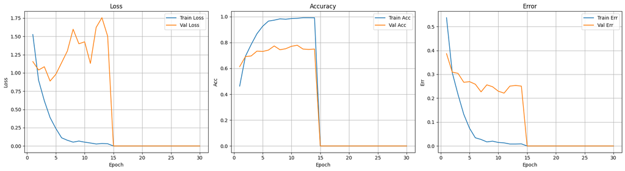

```python
# TO BE COMPLETED

#Setting1
set1 = {
    "lr": 0.001,
    "weight_decay": 1e-5,
    "dropout": 0.1,
    "epochs": 30
}

net1 = CNN(num_classes=9, dropout_p=set1["dropout"])

net1, hist1 = train_net(
    net1,
    train_loader=train_loader,
    val_loader=val_loader,
    learning_rate=set1["lr"],
    weight_decay=set1["weight_decay"],
    num_epochs=set1["epochs"],
)

plot_training_results(hist1)
```

```
Using device: cuda
Early stopping: no val_loss improvement for 10 epochs. Best epoch = 4
Finished Training. Total time elapsed: 89.12 seconds
Restoring model weights from Best Epoch 4
```

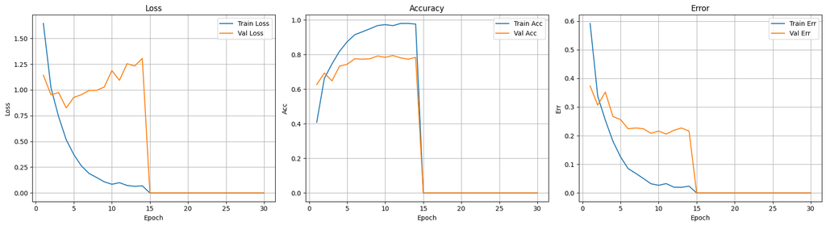

```
Best epoch: 4 best val loss: 0.8255907196998596
```

```python
#Setting2
set2 = {"lr": 1e-3, "weight_decay": 1e-4, "dropout": 0.3, "epochs": 30}

net2 = CNN(num_classes=9, dropout_p=set2["dropout"])
net2, hist2 = train_net(
    net2,
    train_loader=train_loader,
    val_loader=val_loader,
    learning_rate=set2["lr"],
    weight_decay=set2["weight_decay"],
    num_epochs=set2["epochs"],

)

plot_training_results(hist2)
print("Best epoch:", hist2["best_epoch"], "best val loss:", hist2["best_val_loss"])
```

```
Using device: cuda
Early stopping: no val_loss improvement for 10 epochs. Best epoch = 4
Finished Training. Total time elapsed: 88.16 seconds
Restoring model weights from Best Epoch 4
```

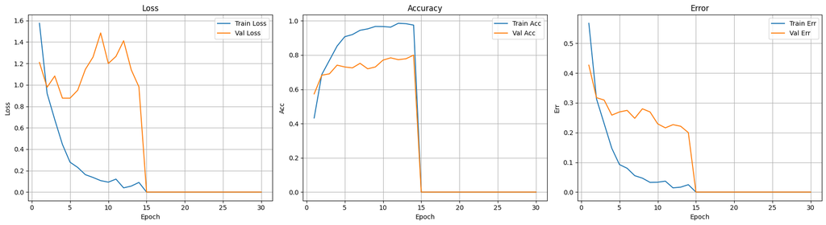

```python
#Setting3
set3 = {"lr": 0.001, "dropout": 0.2, "weight_decay": 5e-4, "epochs": 30}

net3 = CNN(num_classes=9, dropout_p=set3["dropout"])
net3, hist3 = train_net(
    net3,
    train_loader=train_loader,
    val_loader=val_loader,
    learning_rate=set3["lr"],
    weight_decay=set3["weight_decay"],
    num_epochs=set3["epochs"],
)

plot_training_results(hist3)
```

```
Using device: cuda
Early stopping: no val_loss improvement for 10 epochs. Best epoch = 4
Finished Training. Total time elapsed: 88.82 seconds
Restoring model weights from Best Epoch 4
```

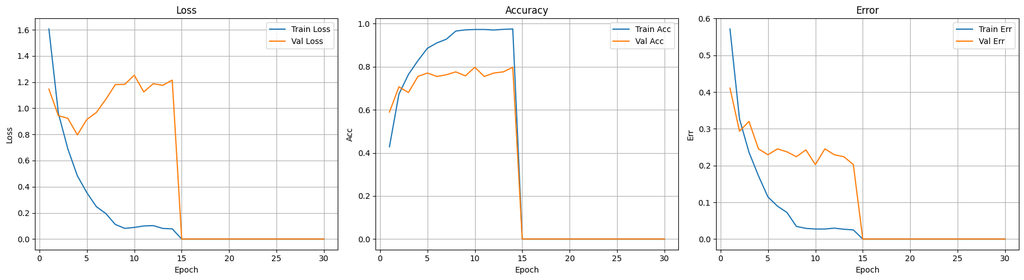

```python
#Setting4
set4 = {"lr": 0.001,  "dropout": 0.25, "weight_decay": 2e-4, "epochs": 30}

net4 = CNN(num_classes=9, dropout_p=set4["dropout"])
net4, hist4 = train_net(
    net4,
    train_loader=train_loader,
    val_loader=val_loader,
    learning_rate=set4["lr"],
    weight_decay=set4["weight_decay"],
    num_epochs=set4["epochs"],
)

plot_training_results(hist4)
```

### Part (iii) - [2pt DISCUSSION]

Choose the best model out of all the ones that you have trained. Justify your choice.

```python
'''
PROVIDE YOUR ANSWER BELOW

The best model is the setting4, since the train_net incorperate early stopping strategy to prevent overfitting,
all the settings are early-stopped.

In setting4, tuned hyperparameters are Learning Rate = 0.001, Dropout = 0.25, Weight Decay = 2e-4

Setting4 achieved a validation error of 24.53% and a training error of 17.21% (a gap of ~7.3%).
In direct comparison to setting 1 (which had lower Dropout rate of 0.1, and WD of 1e-5), the gap was much wider at ~13.4%.
This indicates that the increased Dropout (0.25) and Weight Decay (2e-4) in setting 4 were necessary
to suppress the overfitting observed in setting 1.

Also, the validation loss achieved a significantly lower score of 0.7958. Compared to setting 1 with Loss 0.8883,
setting 4 lowered the validation loss significantly, confirming that the added regularization helped the model generalize
better to unseen data. When we compare to setting 2 with Dropout 0.3 and setting 3 with WD 5e-4,
these settings also had higher validation losses (and lower accuracies). This indicates that their regularization was
likely too aggressive; it constrains the model's capacity to learn.

The results in setting 4 indicates that this model configuration had fewer overfitting patterns compared to the others,
so it learned more generalized features rather than memorizing the training data.




'''
```

### Model Training Checkpoint [0pt OPTIONAL]

To avoid retraining your model every time you work on your assignment, save your best model weights to a file named `part3.pt`. You can then load it later to continue working on the assignment without rerunning the previous cells. There is no need to submit `part3.pt`.

```python
# Save the best model's parameters


torch.save(net4.state_dict(), 'part3.pt')
print("Model weights saved to part3.pt!")
```

```
Model weights saved to part3.pt!
```

```python
# Instantiate your Model class
# We use the hyperparameters from the best model (net4)
model = CNN(num_classes=9, dropout_p=0.25)

# Load the weights
model.load_state_dict(torch.load('part3.pt'))
model.eval() # Set to evaluation mode for inference
print("Model weights loaded!")
```

```
Model weights loaded!
```

### Part (iv) - [2pt RESULTS]

Report the test accuracy of your best model. You should only do this step once and prior to this step you should have only used the training and validation data.

Additionally, provide a confusion matrix to visualize the performance of your model across different classes.

```
Final Test Accuracy: 79.57%
```

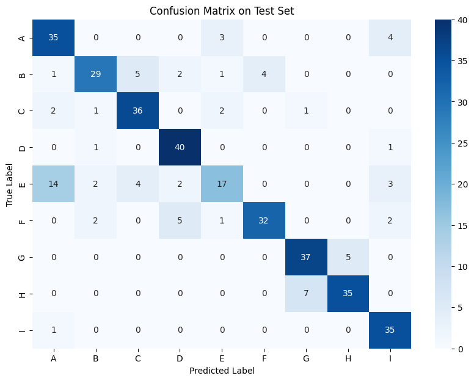

```python
from sklearn.metrics import confusion_matrix
import seaborn as sns
import pandas as pd
import matplotlib.pyplot as plt

# Evaluate on Test Set
device = torch.device("cuda" if torch.cuda.is_available() else "cpu")


model = model.to(device)

test_err, test_loss, test_acc = evaluate(model, test_loader, nn.CrossEntropyLoss(), device)
print(f"Final Test Accuracy: {test_acc:.2%}")

#Generate Confusion Matrix
def get_predictions(net, loader, device):
    all_preds = []
    all_labels = []
    net.eval()
    with torch.no_grad():
        for inputs, labels in loader:
            inputs = inputs.to(device)
            labels = labels.to(device)
            outputs = net(inputs)
            preds = outputs.argmax(dim=1)
            all_preds.extend(preds.cpu().numpy())
            all_labels.extend(labels.cpu().numpy())
    return np.array(all_preds), np.array(all_labels)

preds, targets = get_predictions(model, test_loader, device)

# Plotting
cm = confusion_matrix(targets, preds)
df_cm = pd.DataFrame(cm, index=classes, columns=classes)

plt.figure(figsize=(10, 7))
sns.heatmap(df_cm, annot=True, fmt='d', cmap='Blues')
plt.xlabel("Predicted Label")
plt.ylabel("True Label")
plt.title("Confusion Matrix on Test Set")
plt.show()
```

```python
'''
PROVIDE YOUR ANSWER BELOW

The final test accuracy is 79.57%. The confusion matrix above provides insight into the model performance.
The matrix shows a strong diagonal line. It indicates that the model correctly predict for most classes.




'''
```

## Part 4. Transfer Learning [8pt]

For many image classification tasks, it is generally not a good idea to train a very large deep neural network model from scratch due to the enormous compute requirements and lack of sufficient amounts of training data.

One of the better options is to try using an existing model that performs a similar task to the one you need to solve. This method of utilizing a pre-trained network for other similar tasks is broadly termed **Transfer Learning**. In this assignment, we will use Transfer Learning to extract features from the hand gesture images. Then, train a smaller network to use these features as input and classify the hand gestures.

As you have learned from the CNN lecture, convolution layers extract various features from the images which get utilized by the fully connected layers for correct classification. AlexNet architecture played a pivotal role in establishing Deep Neural Nets as a go-to tool for image classification problems and we will use an ImageNet pre-trained AlexNet model to extract features in this assignment.

### Part (i) - [1pt EXPLORATORY]

Here is the code to load the AlexNet network, with pretrained weights. When you first run the code, PyTorch will download the pretrained weights from the internet.

```python
import torchvision.models
alexnet = torchvision.models.alexnet(pretrained=True)
```

```
Downloading: "https://download.pytorch.org/models/alexnet-owt-7be5be79.pth" to /root/.cache/torch/hub/checkpoints/alexnet-owt-7be5be79.pth
```

The alexnet model is split up into two components: *alexnet.features* and *alexnet.classifier*. The first neural network component, *alexnet.features*, is used to compute convolutional features, which are taken as input in *alexnet.classifier*.

The neural network alexnet.features expects an image tensor of shape Nx3x224x224 as input and it will output a tensor of shape Nx256x6x6 . (N = batch size).

Compute the AlexNet features for each of your training, validation, and test data. Here is an example code snippet showing how you can compute the AlexNet features for some images (your actual code might be different):

```python
# img = ... a PyTorch tensor with shape [N,3,224,224] containing hand images ...
features = alexnet.features(img)
```

**Save the computed features**. You will be using these features as input to your neural network in Part (ii), and you do not want to re-compute the features every time. Instead, run *alexnet.features* once for each image, and save the result.

```python
import os
import torch


device = torch.device("cuda" if torch.cuda.is_available() else "cpu")
alexnet = alexnet.to(device)
alexnet.eval()

def get_features(loader, model, device):
    # Lists to store features and labels
    features_list = []
    labels_list = []

    print(f"Extracting features from {len(loader)} batches...")

    with torch.no_grad():
        for img, label in loader:
            img = img.to(device)
            # Pass image through the convolutional layers (features)
            # Output shape: (Batch_Size, 256, 6, 6)
            feature = model.features(img)

            # Move to CPU to save memory and append
            features_list.append(feature.cpu()) # Detach and move to CPU
            labels_list.append(label)

    # Concatenate all batches
    features = torch.cat(features_list, dim=0)
    labels = torch.cat(labels_list, dim=0)
    return features, labels

# Extract features for all splits
train_features, train_labels = get_features(train_loader, alexnet, device)
val_features, val_labels = get_features(val_loader, alexnet, device)
test_features, test_labels = get_features(test_loader, alexnet, device)

# Save to Drive so we don't have to compute them again
feature_dir = '/content/drive/MyDrive/MIE1517_A2_Data/AlexNet_Features'
os.makedirs(feature_dir, exist_ok=True)

torch.save((train_features, train_labels), os.path.join(feature_dir, 'train_features.pt'))
torch.save((val_features, val_labels), os.path.join(feature_dir, 'val_features.pt'))
torch.save((test_features, test_labels), os.path.join(feature_dir, 'test_features.pt'))

print(f"Features saved to {feature_dir}")
print("Feature shape example (Train):", train_features.shape)
```

```
Extracting features from 53 batches...
Extracting features from 12 batches...
Extracting features from 12 batches...
Features saved to /content/drive/MyDrive/MIE1517_A2_Data/AlexNet_Features
Feature shape example (Train): torch.Size([1685, 256, 6, 6])
```

### Part (ii) - [1pt MODEL]

Build a convolutional neural network that takes as input these AlexNet features, and makes a prediction using additional convolutional and/or linear layers. Your model should be a subclass of nn.Module.

Here is an example of how your model may be called:

```python
# features = ... load precomputed alexnet.features(img) ...
output = model(features)
prob = F.softmax(output)
```

```python
class AlexNetFeatureClassifier(nn.Module):
    def __init__(self, num_classes=9):
        super(AlexNetFeatureClassifier, self).__init__()
        self.name = "AlexNetFeatureClassifier"
        # Input features shape from AlexNet: (Batch_Size, 256, 6, 6)

        # Convolutional layer to reduce depth and extract further spatial patterns
        # Input: 256 channels, Output: 128 channels
        self.conv = nn.Conv2d(in_channels=256, out_channels=128, kernel_size=3, padding=1)

        # Fully connected layers
        # Flattened size: 128 * 6 * 6 = 4608
        self.fc1 = nn.Linear(128 * 6 * 6, 512)
        self.fc2 = nn.Linear(512, num_classes)

        self.dropout = nn.Dropout(0.3)

    def forward(self, x):
        # x shape: [B, 256, 6, 6]
        x = F.relu(self.conv(x))

        # Flatten
        x = x.view(-1, 128 * 6 * 6)

        x = self.dropout(F.relu(self.fc1(x)))
        x = self.fc2(x)
        return x

# Verify model architecture
model_alex = AlexNetFeatureClassifier()
print(model_alex)

# Sanity check with dummy input
dummy_input = torch.randn(2, 256, 6, 6)
print("Output shape:", model_alex(dummy_input).shape)
```

```
AlexNetFeatureClassifier(
  (conv): Conv2d(256, 128, kernel_size=(3, 3), stride=(1, 1), padding=(1, 1))
  (fc1): Linear(in_features=4608, out_features=512, bias=True)
  (fc2): Linear(in_features=512, out_features=9, bias=True)
  (dropout): Dropout(p=0.3, inplace=False)
)
Output shape: torch.Size([2, 9])
```

### Part (iii) - [1pt MODEL]

Train your new network, including any hyperparameter tuning. Plot and submit the training curve of your best model only.

Note: Depending on how you are caching (saving) your AlexNet features, PyTorch might still be tracking updates to the **AlexNet weights**, which we are not tuning. One workaround is to convert your AlexNet feature tensor into a numpy array, and then back into a PyTorch tensor.

```python
tensor = torch.from_numpy(tensor.detach().numpy())
```

```
Loading features from Drive...
Starting training with AlexNet features...
Using device: cuda
Early stopping: no val_loss improvement for 10 epochs. Best epoch = 7
Finished Training. Total time elapsed: 2.44 seconds
Restoring model weights from Best Epoch 7
```

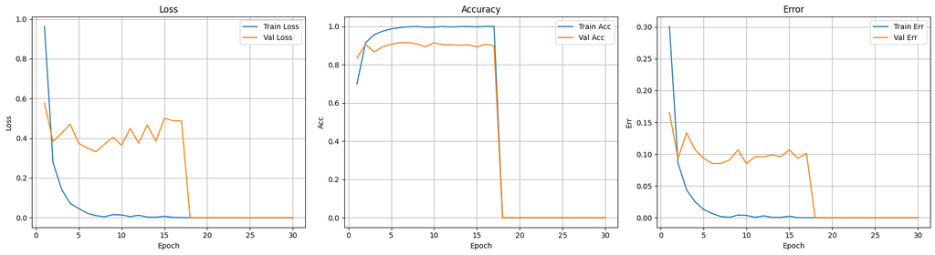

```python
from torch.utils.data import TensorDataset, DataLoader

#Load the pre-computed features
feature_dir = '/content/drive/MyDrive/MIE1517_A2_Data/AlexNet_Features'

print("Loading features from Drive...")
train_features, train_labels = torch.load(os.path.join(feature_dir, 'train_features.pt'))
val_features, val_labels = torch.load(os.path.join(feature_dir, 'val_features.pt'))
test_features, test_labels = torch.load(os.path.join(feature_dir, 'test_features.pt'))

# Create TensorDatasets and DataLoaders
# Note: We can use a larger batch size since features are smaller than images
batch_size = 64

train_data_alex = TensorDataset(train_features, train_labels)
val_data_alex = TensorDataset(val_features, val_labels)
test_data_alex = TensorDataset(test_features, test_labels)

train_loader_alex = DataLoader(train_data_alex, batch_size=batch_size, shuffle=True)
val_loader_alex = DataLoader(val_data_alex, batch_size=batch_size, shuffle=False)
test_loader_alex = DataLoader(test_data_alex, batch_size=batch_size, shuffle=False)

# Train the new classifier
# Hyperparameters for Transfer Learning
alex_config = {
    "lr": 0.001,
    "epochs": 30,
    "weight_decay": 1e-4
}

model_alex = AlexNetFeatureClassifier(num_classes=9)

print("Starting training with AlexNet features...")
model_alex, hist_alex = train_net(
    model_alex,
    train_loader_alex,
    val_loader_alex,
    learning_rate=alex_config["lr"],
    num_epochs=alex_config["epochs"],
    weight_decay=alex_config["weight_decay"],
    save_dir='/content/drive/MyDrive/MIE1517_A2_Data/models_alex'
)

#Plot Training Curve
plot_training_results(hist_alex)
```

### Part (iv) - [1pt RESULTS]

Report the test accuracy of your best model. How does the test accuracy compare to Part 3(iv) without transfer learning?

Additionally, provide a confusion matrix to visualize the performance of your model across different classes.

```
Final Test Accuracy (Transfer Learning): 96.51%
Final Test Accuracy (Part 3 CNN):      79.57%
Improvement: 16.94%
```

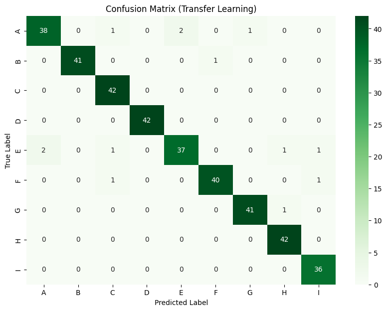

```python
# Evaluate on Test Set (AlexNet Features)
device = torch.device("cuda" if torch.cuda.is_available() else "cpu")
model_alex = model_alex.to(device)

test_err_alex, test_loss_alex, test_acc_alex = evaluate(model_alex,
                                                        test_loader_alex,
                                                        nn.CrossEntropyLoss(),
                                                        device)

print(f"Final Test Accuracy (Transfer Learning): {test_acc_alex:.2%}")

# Compare with Part 3
try:
    print(f"Final Test Accuracy (Part 3 CNN):      {test_acc:.2%}")
    print(f"Improvement: {test_acc_alex - test_acc:.2%}")
except NameError:
    print("Part 3 accuracy variable not found.")

#Generate Confusion Matrix
# Re-using get_predictions from Part 3
preds_alex, targets_alex = get_predictions(model_alex, test_loader_alex, device)

# Plotting
cm_alex = confusion_matrix(targets_alex, preds_alex)
df_cm_alex = pd.DataFrame(cm_alex, index=classes, columns=classes)

plt.figure(figsize=(10, 7))
sns.heatmap(df_cm_alex, annot=True, fmt='d', cmap='Greens') # Changed colormap to distinguish
plt.xlabel("Predicted Label")
plt.ylabel("True Label")
plt.title("Confusion Matrix (Transfer Learning)")
plt.show()
```

```python
'''
PROVIDE YOUR ANSWER BELOW

The final test accuracy for the AlexNet transfer learning model is 96.51%.
Compared to the best model from Part 3, which achieved 79.57%, the transfer learning approach yields a significant improvement of approximately 16.94%.

There is a significant improvement (~17%) after applying transfer learning.
From this experiment, it again domonstrate the powerful of transfer learning. The pre-trained AlexNet has learned rich, robust feature representations
from the massive ImageNet dataset, which generalize very well to our hand gesture task.
The best model from part 3 suggest that our small dataset is insufficient to learn such complex features from scratch without overfitting, it cannot reach the
high accuracy as the pre-trained AlexNet model.

The confusion matrix further confirms this. It shows a very strong diagonal. Comparing this with the part 3 confusion matrix, which struggled to differentiate
between Class E and Class A (14), the current transfer learning confusion matrix shows this differentiate dropped significantly from 14 Class E samples
to just 2 with transfer learning.

'''
```

### Part (v) - Transfer Learning with Another Pretrained Model [1pts EXPLORATORY]

In this section, you will repeat the steps performed in Parts B4(i) to B4(iv) using another pretrained model available in torchvision.models. The goal is to compare the results obtained with AlexNet to those obtained with another model, such as VGG16 or ResNet18 (you can choose your model/s of interest).

```python
# Load the model
import torchvision.models as models

# Load Pretrained ResNet18
resnet = models.resnet18(pretrained=True)

# Output shape will be (Batch_Size, 512, 1, 1)
resnet_features_model = nn.Sequential(*list(resnet.children())[:-1])

resnet_features_model = resnet_features_model.to(device)
resnet_features_model.eval()

#Extract Features (Re-using the logic from Part 4(i))
def get_resnet_features(loader, model, device):
    features_list = []
    labels_list = []
    print(f"Extracting features from {len(loader)} batches")
    with torch.no_grad():
        for img, label in loader:
            img = img.to(device)
            feature = model(img)
            features_list.append(feature.cpu())
            labels_list.append(label)
    return torch.cat(features_list, dim=0), torch.cat(labels_list, dim=0)


train_feat_res, train_lbl_res = get_resnet_features(train_loader, resnet_features_model, device)
val_feat_res, val_lbl_res = get_resnet_features(val_loader, resnet_features_model, device)
test_feat_res, test_lbl_res = get_resnet_features(test_loader, resnet_features_model, device)

#Save to Drive
res_feature_dir = '/content/drive/MyDrive/MIE1517_A2_Data/ResNet_Features'
os.makedirs(res_feature_dir, exist_ok=True)

torch.save((train_feat_res, train_lbl_res), os.path.join(res_feature_dir, 'train_features.pt'))
torch.save((val_feat_res, val_lbl_res), os.path.join(res_feature_dir, 'val_features.pt'))
torch.save((test_feat_res, test_lbl_res), os.path.join(res_feature_dir, 'test_features.pt'))

print(f"ResNet Features saved to {res_feature_dir}")
print("Feature shape example:", train_feat_res.shape)
```

```
Downloading: "https://download.pytorch.org/models/resnet18-f37072fd.pth" to /root/.cache/torch/hub/checkpoints/resnet18-f37072fd.pth
```

```
Extracting features from 53 batches
```

```
Extracting features from 12 batches
Extracting features from 12 batches
ResNet Features saved to /content/drive/MyDrive/MIE1517_A2_Data/ResNet_Features
Feature shape example: torch.Size([1685, 512, 1, 1])
```

### Part (vi) - [1pt MODEL]

Build a convolutional neural network model that makes predictions based on features extracted by your model of interest in Part B4(v). Your model should be a subclass of nn.Module.

```python
class ResNetFeatureClassifier(nn.Module):
    def __init__(self, num_classes=9):
        super(ResNetFeatureClassifier, self).__init__()
        self.name = "ResNetFeatureClassifier"
        # Input shape: (Batch_Size, 512, 1, 1)

        # 1x1 Convolution: Effectively acts as a dense layer but satisfies "CNN" definition
        # Reduces channels from 512 -> 256
        self.conv = nn.Conv2d(in_channels=512, out_channels=256, kernel_size=1)

        # Flatten: (B, 256, 1, 1) -> (B, 256)
        # The spatial dimensions are already 1x1, so this just removes them
        self.fc = nn.Linear(256, num_classes)

        self.dropout = nn.Dropout(0.3)

    def forward(self, x):
        # x: (B, 512, 1, 1)
        x = F.relu(self.conv(x))

        x = x.view(x.size(0), -1) # Flatten

        x = self.dropout(x)
        x = self.fc(x)
        return x

# Sanity Check
model_res = ResNetFeatureClassifier()
print(model_res)
dummy = torch.randn(2, 512, 1, 1)
print("Output shape:", model_res(dummy).shape)
```

```
ResNetFeatureClassifier(
  (conv): Conv2d(512, 256, kernel_size=(1, 1), stride=(1, 1))
  (fc): Linear(in_features=256, out_features=9, bias=True)
  (dropout): Dropout(p=0.3, inplace=False)
)
Output shape: torch.Size([2, 9])
```

### Part (vii) - [1pt MODEL]

Train your new network, including any hyperparameter tuning. Plot and submit the training curve of your best model only.

```
Loading ResNet features...
Starting training with ResNet features...
Using device: cuda
Finished Training. Total time elapsed: 2.01 seconds
Restoring model weights from Best Epoch 27
```

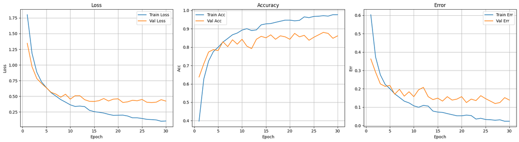

```python
# Load ResNet Features
res_feature_dir = '/content/drive/MyDrive/MIE1517_A2_Data/ResNet_Features'


train_feat_res, train_lbl_res = torch.load(os.path.join(res_feature_dir, 'train_features.pt'))
val_feat_res, val_lbl_res = torch.load(os.path.join(res_feature_dir, 'val_features.pt'))
test_feat_res, test_lbl_res = torch.load(os.path.join(res_feature_dir, 'test_features.pt'))

# Create DataLoaders
batch_size = 64
train_data_res = TensorDataset(train_feat_res, train_lbl_res)
val_data_res = TensorDataset(val_feat_res, val_lbl_res)
test_data_res = TensorDataset(test_feat_res, test_lbl_res)

train_loader_res = DataLoader(train_data_res, batch_size=batch_size, shuffle=True)
val_loader_res = DataLoader(val_data_res, batch_size=batch_size, shuffle=False)
test_loader_res = DataLoader(test_data_res, batch_size=batch_size, shuffle=False)

# Train the ResNet Classifier
res_config = {
    "lr": 0.001,
    "epochs": 30,
    "weight_decay": 1e-4
}

model_res = ResNetFeatureClassifier(num_classes=9)

model_res, hist_res = train_net(
    model_res,
    train_loader_res,
    val_loader_res,
    learning_rate=res_config["lr"],
    num_epochs=res_config["epochs"],
    weight_decay=res_config["weight_decay"],
    save_dir='/content/drive/MyDrive/MIE1517_A2_Data/models_res'
)

# Plot Training Curve
plot_training_results(hist_res)
```

### Part (viii) - [1pt RESULTS]

Compare the performance of AlexNet (Part B4(iv)) and the other pretrained model you selected (Part B4(vii)). Discuss the differences in performance between AlexNet and the new model.

```
Final Test Accuracy (ResNet18): 90.32%
----------------------------------------
AlexNet Test Accuracy: 96.51%
ResNet18 Test Accuracy: 90.32%
----------------------------------------
```

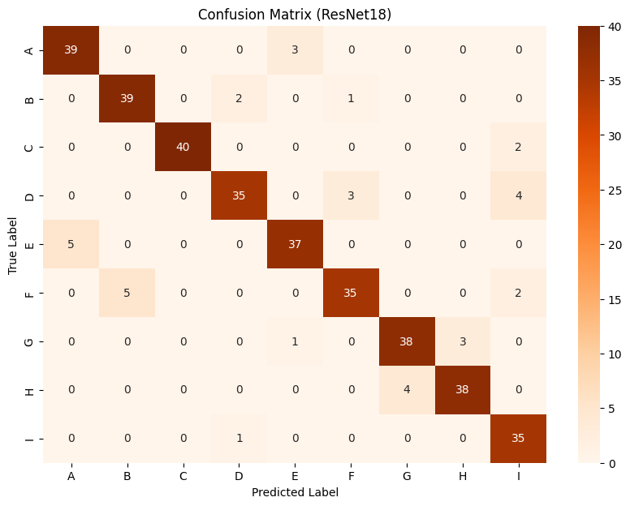

```python
# Evaluate ResNet on Test Set
device = torch.device("cuda" if torch.cuda.is_available() else "cpu")
model_res = model_res.to(device)

test_err_res, test_loss_res, test_acc_res = evaluate(model_res, test_loader_res, nn.CrossEntropyLoss(), device)

print(f"Final Test Accuracy (ResNet18): {test_acc_res:.2%}")

# Compare with AlexNet
try:
    print("-" * 40)
    print(f"AlexNet Test Accuracy: {test_acc_alex:.2%}")
    print(f"ResNet18 Test Accuracy: {test_acc_res:.2%}")
    print("-" * 40)
except NameError:
    print("AlexNet accuracy variable not found.")

# Confusion Matrix for ResNet
preds_res, targets_res = get_predictions(model_res, test_loader_res, device)

cm_res = confusion_matrix(targets_res, preds_res)
df_cm_res = pd.DataFrame(cm_res, index=classes, columns=classes)

plt.figure(figsize=(10, 7))
sns.heatmap(df_cm_res, annot=True, fmt='d', cmap='Oranges')
plt.xlabel("Predicted Label")
plt.ylabel("True Label")
plt.title("Confusion Matrix (ResNet18)")
plt.show()
```

```python
'''
PROVIDE YOUR ANSWER BELOW

Comparison:
While both pretrained models had significantly higher accuracy than the custom CNN from Part 3 (79%),
AlexNet (96.51%) performed better than ResNet18 (90.32%).

The result is interesting since ResNet is considered as a newer and stronger net than AlexNet, but in the current experiment, the result is out of this expectation.

Discussion:
In hand gesture recognition, spatial information, such as the specific location of fingers relative to the palm, is important for distinguishing between similar classes.
Just like Class A and Class E, the two classes that were often hard to distinguish by the model. Both involve a compact, closed-fist structure, making them hard to
differentiate. If we consider from the model perspective, they share similar low-level visual features. Therefore, if the model has less ability in preserving spatial
grid information, it would be more likely that this model predicts the incorrect hand guesture.

AlexNet's feature output is 6x6, this output preserve the spatial information, the image is not fully flattened like in ResNet, which output is 1x1.
Therefore, the spatial preserving advantage in AlexNet's output help it achieve better performance than ResNet.



'''
```

### Model Training Checkpoint [0pt OPTIONAL]

To avoid retraining your model every time you work on your assignment, save your best model weights to a file named `part4.pt`. You can then load it later to continue working on the assignment without rerunning the previous cells. There is no need to submit `part4.pt`.

```python
'''
SAVE YOUR MODEL PARAMETERS
'''

# Save the weights
torch.save(model_alex.state_dict(), 'part4.pt')
print("Model weights saved!")
```

```
Model weights saved!
```

```python
'''
LOAD YOUR MODEL PARAMETERS
'''

# Instantiate your Model class
# We replace the placeholder 'Model()' with our actual class
model = AlexNetFeatureClassifier(num_classes=9)

# Load the weights
model.load_state_dict(torch.load('part4.pt'))
model.eval()
print("Model weights loaded!")
```

```
Model weights loaded!
```

## Part 5. Testing on New Data [14pt]

In this final step, we will evaluate the models trained using new data that was not part of the training process. In this assignment, there will be three different test datasets:

1. The test dataset generated by splitting the labeled data provided in the file `A2_Hand_Gesture_Dataset_revised.zip` into train, validation, and test sets. It is used throughout Part B1 to B4.
2. The data you collected in Part A.
3. The unlabeled data provided in `A2_Hand_Gesture_Unlabeled_Data.zip`.

### Part (i) - [2pt EXPLORATORY]

Load and process the hand gesture images you had collected so that they can easily be evaulated by your model.

```python
import zipfile
from PIL import Image
import torch
from torch.utils.data import Dataset, DataLoader
from torchvision import transforms
import glob

#Unzip the file
zip_path = '/content/Xu_1007901512.zip'
extract_path = '/content/my_data'

if os.path.exists(zip_path):
    print(f"Unzipping {zip_path}")
    with zipfile.ZipFile(zip_path, 'r') as zip_ref:
        zip_ref.extractall(extract_path)
else:
    print(f"Error: {zip_path} not found. ")

#Define Custom Dataset
class MyGestureDataset(Dataset):
    def __init__(self, root_dir, transform=None):
        self.root_dir = root_dir
        self.transform = transform
        # Find all .jpg images recursively
        self.image_paths = sorted(glob.glob(os.path.join(root_dir, '**', '*.jpg'), recursive=True))
        self.classes = ['A', 'B', 'C', 'D', 'E', 'F', 'G', 'H', 'I']
        self.class_to_idx = {c: i for i, c in enumerate(self.classes)}

    def __len__(self):
        return len(self.image_paths)

    def __getitem__(self, idx):
        img_path = self.image_paths[idx]
        image = Image.open(img_path).convert('RGB')

        filename = os.path.basename(img_path)
        try:
            # Split by '_' and take the second part
            label_str = filename.split('_')[1]
            label = self.class_to_idx[label_str]
        except (IndexError, KeyError):
            print(f"Warning: Could not parse label from {filename}, skipping")
            label = 0 # Default fallback

        if self.transform:
            image = self.transform(image)

        return image, label

#Create DataLoader
# Use exactly the same transform as training
my_transform = transforms.Compose([
    transforms.Resize((224, 224)),
    transforms.ToTensor(),
    transforms.Normalize(mean=[0.485, 0.456, 0.406], std=[0.229, 0.224, 0.225])
])

my_dataset = MyGestureDataset(root_dir=extract_path, transform=my_transform)
my_loader = DataLoader(my_dataset, batch_size=32, shuffle=False)

print(f"Successfully loaded {len(my_dataset)} images from Part A.")

# Sanity check: show one label
if len(my_dataset) > 0:
    _, lbl = my_dataset[0]
    print(f"Sample Check - Label index: {lbl}, Class: {my_dataset.classes[lbl]}")
```

```
Unzipping /content/Xu_1007901512.zip
Successfully loaded 27 images from Part A.
Sample Check - Label index: 0, Class: A
```

### Part (ii) - [2pt RESULTS]

Using the best transfer learning model developed in Part 4. Report the test accuracy on your sample images and how it compares to the test accuracy obtained in Part 4(iv)? Also, use your best model from Part 3 to report the test accuracy on the new sample images and how it compares to the test accuracy obtained in Part 3(iv). You should present your results in a pandas DataFrame.

This question will also be evaluated on the overal performance achieved.

```python
#Evaluate Part 3 Model (CNN) on New Data
cnn_part3 = CNN(num_classes=9, dropout_p=0.25).to(device)
if os.path.exists('part3.pt'):
    cnn_part3.load_state_dict(torch.load('part3.pt'))
    cnn_part3.eval()
    # Part 3 model takes raw images, so we can use the standard evaluate function
    _, _, my_acc_part3 = evaluate(cnn_part3, my_loader, nn.CrossEntropyLoss(), device)
    print(f"Part 3 Accuracy on My Data: {my_acc_part3:.2%}")
else:
    print("Error: part3.pt not found.")
    my_acc_part3 = 0.0

#Evaluate Part 4 Model (AlexNet Transfer) on New Data
model_part4 = AlexNetFeatureClassifier(num_classes=9).to(device)
if os.path.exists('part4.pt'):
    model_part4.load_state_dict(torch.load('part4.pt'))
    model_part4.eval()

    # Helper to evaluate pipeline: Image -> AlexNet Features -> Classifier
    correct = 0
    total = 0
    alexnet.to(device)
    alexnet.eval()

    with torch.no_grad():
        for images, labels in my_loader:
            images, labels = images.to(device), labels.to(device)
            # Step A: Extract features using AlexNet
            features = alexnet.features(images)
            # Step B: Predict using our classifier
            outputs = model_part4(features)

            preds = outputs.argmax(dim=1)
            correct += (preds == labels).sum().item()
            total += labels.size(0)

    my_acc_part4 = correct / total
    print(f"Part 4 Accuracy on My Data: {my_acc_part4:.2%}")
else:
    print("Error: part4.pt not found.")
    my_acc_part4 = 0.0

#Present Results in DataFrame
# Retrieve previous test accuracies if available, else 0
org_acc_p3 = test_acc if 'test_acc' in locals() else 0.0
org_acc_p4 = test_acc_alex if 'test_acc_alex' in locals() else 0.0

results_df = pd.DataFrame({
    "Model": ["Part 3 (CNN From Scratch)", "Part 4 (Transfer Learning)"],
    "Test Acc (Original Dataset)": [org_acc_p3, org_acc_p4],
    "Test Acc (My New Data)": [my_acc_part3, my_acc_part4]
})

# Formatting for display
pd.options.display.float_format = '{:.2%}'.format
display(results_df)
```

```
Part 3 Accuracy on My Data: 70.37%
Part 4 Accuracy on My Data: 74.07%
```

|  | Model | Test Acc (Original Dataset) | Test Acc (My New Data) |
| --- | --- | --- | --- |
| 0 | Part 3 (CNN From Scratch) | 79.57% | 70.37% |
| 1 | Part 4 (Transfer Learning) | 96.51% | 74.07% |

### Part (iii) - [3pt RESULTS]

Load the unlabeled hand gesture images from the supplementary assignment files on Quercus (`A2_Hand_Gesture_Unlabeled_Data.zip`), which contains 1000 unlabeled images. Using the best transfer learning model developed in Part 4, classify all 1000 images and save the results in a .CSV file with the following format (Note: The file will be evaluated using an automated Python script to assess your model's performance, so make sure to follow the format precisely).

Example .csv file:

```
1,A
2,B
3,C
4,H
...
..
1000,I
```

```python
import re

#Unzip the Unlabeled Data
# Try to locate the file in Drive first
unlabeled_zip_path = '/content/drive/MyDrive/MIE1517_A2_Data/A2_Hand_Gesture_Unlabeled_Data.zip'
extract_unlabeled_path = '/content/unlabeled_data'

if not os.path.exists(unlabeled_zip_path):
    # Fallback to local upload if not in drive
    unlabeled_zip_path = '/content/A2_Hand_Gesture_Unlabeled_Data.zip'

if os.path.exists(unlabeled_zip_path):
    print(f"Unzipping {unlabeled_zip_path}...")
    with zipfile.ZipFile(unlabeled_zip_path, 'r') as zip_ref:
        zip_ref.extractall(extract_unlabeled_path)
else:
    print(f"Error: {unlabeled_zip_path} not found. Please upload or check path.")

#Define Unlabeled Dataset
class UnlabeledDataset(Dataset):
    def __init__(self, root_dir, transform=None):
        self.root_dir = root_dir
        self.transform = transform
        self.image_paths = sorted(glob.glob(os.path.join(root_dir, '**', '*.jpg'), recursive=True))

    def __len__(self):
        return len(self.image_paths)

    def __getitem__(self, idx):
        img_path = self.image_paths[idx]
        image = Image.open(img_path).convert('RGB')

        # Extract ID from filename (e.g. "123.jpg" -> 123)
        filename = os.path.basename(img_path)
        # Use regex to find the number in the filename
        match = re.search(r'(\d+)', filename)
        if match:
            img_id = int(match.group(1))
        else:
            img_id = -1 # Should not happen based on description

        if self.transform:
            image = self.transform(image)

        return image, img_id

#Create DataLoader
unlabeled_dataset = UnlabeledDataset(root_dir=extract_unlabeled_path, transform=my_transform)
unlabeled_loader = DataLoader(unlabeled_dataset, batch_size=32, shuffle=False)

print(f"Found {len(unlabeled_dataset)} unlabeled images.")

#redict using Best Model (model_alex)
model_part4.eval()
alexnet.eval()

all_ids = []
all_preds = []

with torch.no_grad():
    for images, ids in unlabeled_loader:
        images = images.to(device)

        # Pipeline: AlexNet Features -> Classifier
        features = alexnet.features(images)
        outputs = model_part4(features)

        preds = outputs.argmax(dim=1)

        all_ids.extend(ids.numpy())
        all_preds.extend(preds.cpu().numpy())

#Process and Save to CSV
# Combine into a list of tuples and sort by ID
results = []
classes_list = ['A', 'B', 'C', 'D', 'E', 'F', 'G', 'H', 'I']

for img_id, pred_idx in zip(all_ids, all_preds):
    pred_char = classes_list[pred_idx]
    results.append((img_id, pred_char))

# Sort by ID (1, 2, 3...)
results.sort(key=lambda x: x[0])

# Write to CSV
student_number = '1007901512'
output_csv = f"{student_number}.csv"

with open(output_csv, 'w') as f:
    for img_id, pred_char in results:
        f.write(f"{img_id},{pred_char}\n")

print(f"Predictions saved to {output_csv}")
print(f"Total lines written: {len(results)}")

# Verify first few lines
print("First 5 predictions:")
for i in range(5):
    if i < len(results):
        print(results[i])
```

```
Unzipping /content/A2_Hand_Gesture_Unlabeled_Data.zip...
Found 1000 unlabeled images.
Predictions saved to 1007901512.csv
Total lines written: 1000
First 5 predictions:
(np.int64(1), 'A')
(np.int64(2), 'F')
(np.int64(3), 'D')
(np.int64(4), 'I')
(np.int64(5), 'E')
```

```python
# Verify the generated CSV file
csv_path = '1007901512.csv'

if os.path.exists(csv_path):
    print(f"Reading {csv_path}...")
    with open(csv_path, 'r') as f:
        lines = f.readlines()

    print(f"Total lines: {len(lines)}")
    print("First 10 lines:")
    for line in lines[:10]:
        print(line.strip())

    # Check format of the first line
    if len(lines) > 0:
        parts = lines[0].strip().split(',')
        if len(parts) == 2 and parts[0].isdigit() and parts[1] in ['A', 'B', 'C', 'D', 'E', 'F', 'G', 'H', 'I']:
            print("\nFormat check passed: [ID, Label]")
        else:
            print(f"\nWarning: Line format might be incorrect: {lines[0].strip()}")
else:
    print(f"Error: {csv_path} not found.")
```

```
Reading 1007901512.csv...
Total lines: 1000
First 10 lines:
1,A
2,F
3,D
4,I
5,E
6,D
7,E
8,B
9,G
10,H

Format check passed: [ID, Label]
```

### Part (iv) - [5pt DISCUSSION]

How well did your models do for the different hand guestures? Provide an explanation for why you think your models performed the way it did? Be sure to compare the results for three test datasets mentioned in part B5. You can refer to the confusion matrices presented earlier.

How well would this model perform if you were to deploy it in the real-world? List some things you could do to improve the model performance.

```python
'''
PROVIDE YOUR ANSWER BELOW

The performance of all models are dropped.

Performance on My data:
  The transfered AlexNet achieved an accuracy of 74.07%, which is a significant drop from its original test accuracy of 96.51%.
  The custom CNN from Part 3 achieved 70.37%, which has a much smaller relative drop from its original 79.57%.
  While the Transfer Learning model still perform better than the custom CNN, it demostrates a much more severe performance degradation
  when exposed to completely unseen data. This indicates that while transfer learning is powerful, it is not immune to domain shifts.

Domain Shift:
  This idea means the training data and the new data look different. The background, lighting, and camera can change. So the model may not generalize well.
  The change between the model's accuracy on the original data set and my own hand data set would be explained by this idea.
  The models were trained on a specific "source domain" (the original dataset), which likely had consistent patterns that were captured by the two models.
  My collected data represents a "target domain" with different environmental factors. For AlexNet's huge drop on accuracy may indicate AlexNet could have overfit the particular details of the source domain.
  High-capacity models tend to learn to exploit the particular, non-robust details of the source domain that allow it to reach near-perfect accuracy. However, when these details are not present in my personal data,
  the model fails to generalize well, resulting in a drastic drop in performance. This is an interesting observation because, despite applying Dropout to the model, the domain shift problem still exists.


Real world application:
If this model were to be deployed in a real-world application, its current performance on new data would not likely to be well performed for a smooth user experience.
Users would experience frequent misclassifications if their lighting or background didn't match the training data perfectly. It could be a burden for their lives.

To address these limitations and improve the model's robustness for real-world deployment, we should bridge the domain gap between the clean training environment and chaotic real-world scenarios.

    First, we can use data augmentation, but in a more aggressive mode during training, since we believe the AlexNet is overfitting, to have the dropped accuracy.
    Data augmentation is a great way to manage this issue. By applying transformations such as random rotations, color jittering, and background substitution,
    we can force the model to learn features that are invariant to lighting changes and environmental clutter.

    Second, the training data itself should be augmented to cover various images that depict different skin tones, camera views, and lighting setups,
    making the model less dependent on source-domain features.

    Lastly, instead of relying on the fixed feature extractor, fine-tuning the pre-trained model by unfreezing the convolutional layers would enable the network to learn its feature
    extractors specifically for hand structural patterns, as opposed to the general ImageNet features, thus greatly improving its generalization performance.



DECLARATION: (ChatGPT was used to inspire me about the point of the domain shifts.)




'''
```

### Part (v) - [2pt DISCUSSION]

Reflect on the ethical implications of deploying a hand gesture recognition model in real-world applications. What are some potential biases that could arise in your model, and how might they impact different user groups?

Discuss measures you can take to identify and mitigate these biases during the development and deployment phases. Consider aspects such as data collection, model training, and user feedback.

```python
'''
PROVIDE YOUR ANSWER BELOW

If applying this model in real-world,

The potential biases could be:

1. Skin Tone Bias: the dataset used for this assignment or many other public dataset tend to not represent darker skin tones or particular
  lighting conditions that affect the reflection of light on the skin. A model trained on mostly lighter skin tone data might not correctly identify
  gestures from users with darker skin. This could create a discriminatory user experience, which can have serious consequence.
  To mitigate this, we should intentionally collect more diverse datasets across skin tones and lighting, then evaluate performance with subgroup metrics,
  such as accuracy/FNR by skin tone and illumination, and apply targeted augmentations (brightness/contrast, shadows) or re-weighting to reduce performance gaps.

2. Privacy: using a hand gesture recognition model would often require users to turn on their cameras, and it could involve privacy issue.
   One of the biggest risks in privacy is the discrepancy between what the users assume is captured by the camera and what actually is captured.
   Many times, in many applications, the UI may only show or indicate the camera is capturing part of an image or video, for example, only the hand area.
   However, the opposite may actually be captured by the camera, like the faces or surroundings, and the cropping may only be done on the camera in the video or image itself.
   To solve this problem, the application should clearly indicate what is captured by the camera, reduce the risk of collection, and clearly show users when recording is active.

3. Hand gesture recognition is more likely to be used for accessibility contexts, such as helping with hearing or speaking difficulties populations.
   However, users may vary in dexterity and range of motion due to injuries, arthritis, tremors, or limb differences. If the model is trained mostly with "ideal" gesture forms,
   it may have systematic misrecognition of such users as an accessibility barrier. To address this bias, we should make sure that our dataset
   contains a variety of different gesture variations in order to evaluate the performance of users with mobility profiles that could result from a wide
   variety of factors when ethically appropriate.




'''
```

### PART C (Optional) - Bonus Challenge!

This is an optional exercise for those that finish the assignment early and would like to take on some additional challenging task.

For this bonus challenge you are asked to explore different techniques to further improve the model for more realistic scenarios where the hands may be in front of various backgrounds, be taken at different scales, rotations, and positions in the image. To build a superior image classification model you can complete one or all of the following tasks.

Tasks:

1. Test your best models (with or without transfer learning) on hand gestures images with backgrounds that are not clean and smooth. You can take your own hand gesture images, or find ones online to test your model. Comment on the performance of your model.
2. Generated additional data by performing data augmentation to replace the clean, smooth backgrounds with backgrounds with different textures. Do this on all your training, validation, and test data. This task can be done manually (could take a long time) or you can implement code that can automate the task. For Example, one approach you could take to automate this task is to use pretrained image segmentation tools to identify the hands in the images and crop them out and put them onto other backgrounds.
3. Implement one of many region proposal tools to detect hand gestures in image frames and put a bounding box around the region with the highest confidence. You can use pretrained YOLO models, or a region proposal tool from openCV.
4. Create a short video demonstration how you can use your hand gesture recognition model to communicate a message using hand gestures.

Bonus marks will be provided based on the number of steps completed. Summarize below your results and anything intersting you learned from the steps that you completed. Bonus marks cannot be accumulated beyond the maximum assignment grade.

```
Testing images in: /content/asl_alphabet_test

Stress Test Accuracy: 55.56% (5/9)
```

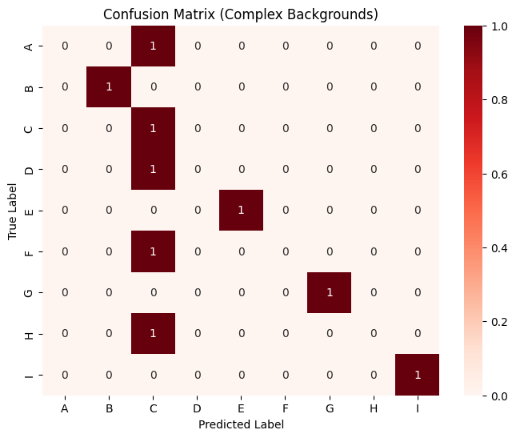

```python
# Task 1: Stress Test
import glob, os, random
import torch
import torch.nn as nn
import torch.nn.functional as F
import pandas as pd
import seaborn as sns
import matplotlib.pyplot as plt
from PIL import Image
from torch.utils.data import Dataset, DataLoader
from torchvision import transforms, models
from sklearn.metrics import confusion_matrix

# 1. Setup & Model Definition
device = torch.device("cuda" if torch.cuda.is_available() else "cpu")

transform = transforms.Compose([
    transforms.Resize((224, 224)),
    transforms.ToTensor(),
    transforms.Normalize(mean=[0.485, 0.456, 0.406], std=[0.229, 0.224, 0.225])
])

class AlexNetFeatureClassifier(nn.Module):
    def __init__(self, num_classes=9):
        super(AlexNetFeatureClassifier, self).__init__()
        self.conv = nn.Conv2d(256, 128, kernel_size=3, padding=1)
        self.fc1 = nn.Linear(128 * 6 * 6, 512)
        self.fc2 = nn.Linear(512, num_classes)
        self.dropout = nn.Dropout(0.3)

    def forward(self, x):
        x = F.relu(self.conv(x))
        x = x.view(-1, 128 * 6 * 6)
        x = self.dropout(F.relu(self.fc1(x)))
        x = self.fc2(x)
        return x

# Load Weights
alexnet = models.alexnet(pretrained=True).to(device).eval()
model_bonus = AlexNetFeatureClassifier(num_classes=9).to(device)
model_bonus.load_state_dict(torch.load('part4.pt', map_location=device))
model_bonus.eval()

classes = ['A', 'B', 'C', 'D', 'E', 'F', 'G', 'H', 'I']

# 2. Dataset
class StressTestDataset(Dataset):
    def __init__(self, root_dir, transform=None):
        self.image_paths = sorted(glob.glob(os.path.join(root_dir, '**', '*.jpg'), recursive=True) +
                                  glob.glob(os.path.join(root_dir, '**', '*.jpeg'), recursive=True))
        self.transform = transform
    def __len__(self): return len(self.image_paths)
    def __getitem__(self, idx):
        path = self.image_paths[idx]
        img = Image.open(path).convert('RGB')
        label = os.path.basename(path).split('_')[0]
        if label not in classes: label = os.path.basename(os.path.dirname(path))
        if self.transform: img = self.transform(img)
        return img, label, path

# 3. Execution
target_dir = '/content/asl_alphabet_test'
dataset = StressTestDataset(root_dir=target_dir, transform=transform)
loader = DataLoader(dataset, batch_size=32, shuffle=False)

all_preds, all_labels = [], []
with torch.no_grad():
    for images, raw_labels, _ in loader:
        images = images.to(device)
        outputs = model_bonus(alexnet.features(images))
        _, preds = torch.max(F.softmax(outputs, dim=1), dim=1)
        for i in range(len(images)):
            all_preds.append(classes[preds[i].item()])
            all_labels.append(raw_labels[i])

# 4. Results
correct = sum([t == p for t, p in zip(all_labels, all_preds)])
print(f"Stress Test Accuracy: {correct/len(all_labels):.2%} ({correct}/{len(all_labels)})\n")

cm = confusion_matrix(all_labels, all_preds, labels=classes)
plt.figure(figsize=(8, 6))
sns.heatmap(pd.DataFrame(cm, index=classes, columns=classes), annot=True, fmt='d', cmap='Reds')
plt.xlabel("Predicted"); plt.ylabel("True"); plt.title("Confusion Matrix (Complex Backgrounds)")
plt.show()
```

```python
'''
PROVIDE YOUR ANSWER BELOW

When testing the accuracy of the most effective transfer learning model, Alexnet, on our realistic images with complex backgrounds and strong backlighting,
the accuracy fell to 55.56% (5/9), which shows a large domain shift from the clean and well-lit training distribution. The confusion matrix shows a
strong bias towards predicting class C,  in which several different gestures (A, D, F, H) are confused with Class C. This is likely because the backlighting
causes the hand to look unclear. Therefore, the image's lighting conditions eliminate the fine-grained details of the fingers,
which are essential for distinguishing between similar gestures.

Reference: https://www.kaggle.com/datasets/grassknoted/asl-alphabet



'''
```

```
Source: /content/local_data/Lab_3b_Gesture_Dataset Revised
Target: /content/augmented_data
```

```
Success,Created 2432 augmented images.
```

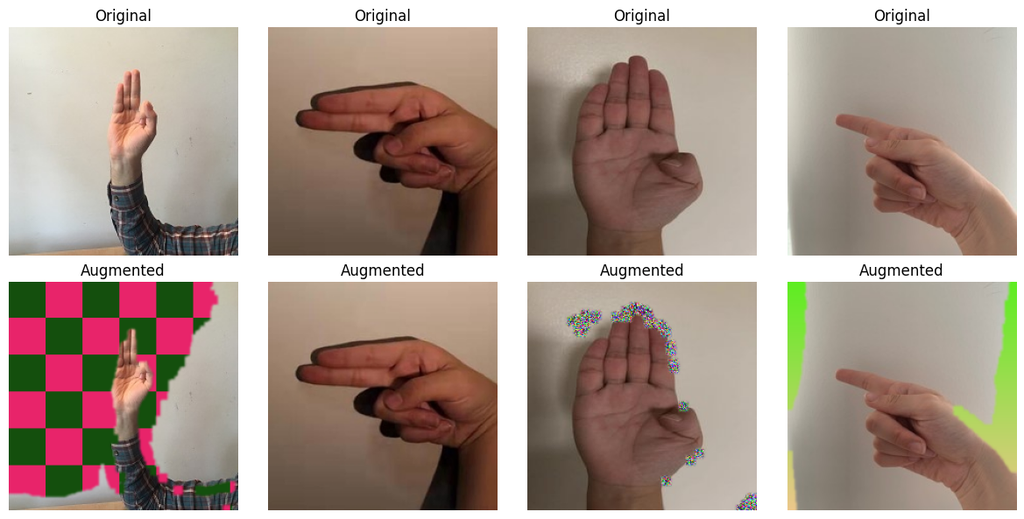

```python
#Task 2:

import cv2
import numpy as np
import os
import glob
from tqdm import tqdm
import matplotlib.pyplot as plt

def gen_noise_bg(shape):
    return np.random.randint(0, 255, shape, dtype=np.uint8)

def gen_gradient_bg(shape):
    h, w, c = shape
    img = np.zeros((h, w, c), dtype=np.uint8)
    c1 = np.random.randint(0, 255, 3)
    c2 = np.random.randint(0, 255, 3)

    # Linear interpolation
    for i in range(h):
        alpha = i / h
        color = (1 - alpha) * c1 + alpha * c2
        img[i, :, :] = color
    return img

def gen_checker_bg(shape):
    """
    Generates a checkerboard pattern.

    """
    h, w, c = shape
    img = np.zeros((h, w, c), dtype=np.uint8)
    sq_size = np.random.randint(20, 50)  # Randomize square size
    c1 = np.random.randint(0, 255, 3)
    c2 = np.random.randint(0, 255, 3)

    for y in range(0, h, sq_size):
        for x in range(0, w, sq_size):
            if ((x // sq_size) + (y // sq_size)) % 2 == 0:
                img[y:y+sq_size, x:x+sq_size] = c1
            else:
                img[y:y+sq_size, x:x+sq_size] = c2
    return img[:h, :w, :]

def augment_image(image_path, save_path):
    """
    Reads an image, segments the hand using HSV,
    and swaps the background.

    """
    img = cv2.imread(image_path)
    if img is None:
        return None

    img = cv2.cvtColor(img, cv2.COLOR_BGR2RGB)

    # Convert to HSV for better skin/background separation
    hsv = cv2.cvtColor(img, cv2.COLOR_RGB2HSV)

    # Define threshold for white background
    # (Low saturation, High value usually indicates white/bright background)
    lower_white = np.array([0, 0, 200])
    upper_white = np.array([180, 50, 255])

    # Create binary mask: 1 for BG, 0 for Hand
    bg_mask = cv2.inRange(hsv, lower_white, upper_white)

    # Clean up the mask using morphological operations
    kernel = np.ones((5,5), np.uint8)
    bg_mask = cv2.dilate(bg_mask, kernel, iterations=2)
    bg_mask = cv2.GaussianBlur(bg_mask, (5, 5), 0)

    # Invert to get hand mask
    hand_mask = cv2.bitwise_not(bg_mask)
    mask_norm = hand_mask[:, :, None] / 255.0

    # Generate a random background
    generators = [gen_noise_bg, gen_gradient_bg, gen_checker_bg]
    chosen_bg = np.random.choice(generators)(img.shape)

    # Composite: Hand * Mask + NewBG * (1 - Mask)
    final_img = (img * mask_norm + chosen_bg * (1 - mask_norm)).astype(np.uint8)

    # Save result (convert back to BGR for OpenCV)
    final_img_bgr = cv2.cvtColor(final_img, cv2.COLOR_RGB2BGR)
    cv2.imwrite(save_path, final_img_bgr)

    return img, final_img

# Main execution block
source_dir = '/content/local_data/Lab_3b_Gesture_Dataset Revised'
output_dir = '/content/augmented_data'

print(f"Source: {source_dir}")
print(f"Target: {output_dir}")

# Find all images
all_images = glob.glob(os.path.join(source_dir, '**', '*.jpg'), recursive=True)

if not all_images:
    print("No images found. Please check the source directory.")
else:
    samples = []

    # Process images with progress bar
    for i, path in enumerate(tqdm(all_images, desc="Processing")):
        # Replicate directory structure
        rel_path = os.path.relpath(path, source_dir)
        out_path = os.path.join(output_dir, rel_path)
        os.makedirs(os.path.dirname(out_path), exist_ok=True)

        # Augment
        original, augmented = augment_image(path, out_path)

        # Save a few examples for visualization later
        if i % 500 == 0 and augmented is not None:
            samples.append((original, augmented))

    print(f"\nSuccess,Created {len(all_images)} augmented images.")

    # Visualization
    if samples:
        plt.figure(figsize=(12, 6))
        for i, (orig, aug) in enumerate(samples[:4]):
            # Show Original
            plt.subplot(2, 4, i + 1)
            plt.imshow(orig)
            plt.title("Original")
            plt.axis('off')

            # Show Augmented
            plt.subplot(2, 4, i + 5)
            plt.imshow(aug)
            plt.title("Augmented")
            plt.axis('off')
        plt.tight_layout()
        plt.show()
```

### Saving to HTML

Detailed instructions for saving to HTML can be found [here](https://stackoverflow.com/questions/53460051/convert-ipynb-notebook-to-html-in-google-colab/64487858#64487858). Provided below are a summary of the instructions:

(1) download your ipynb file by clicking on File->Download.ipynb

(2) reupload your file to the temporary Google Colab storage (you can access the temporary storage from the tab to the left)

(3) run the following:

```python
from google.colab import drive
drive.mount('/content/drive')
```

```python
%%shell
jupyter nbconvert --to html /content/drive/MyDrive/A2.ipynb
```

(4) the html file will be available for download in the temporary Google Colab storage

(5) review the html file and make sure all the results are visible before submitting your assignment to Quercus

# Assignment Grading Rubric

The grading of the assignment will be based on the following categories:

(0) **5 Pt - DATA** Generating new data to evaluate your model.

(1) **9 Pt - EXPLORATORY QUESTIONS** These are basic questions that in most cases can be answered without requiring a fully working and trained neural network model. For example, data loading, processing and visualization, summary statistics, data exploration, model and training setup, etc.

(2) **9 Pt - MODEL** Student has successfully implemented all the required neural network models and has demonstrated successful training of the model without any errors.

(3) **9 Pt - RESULT** Students are evaluated based on the results achieved in comparison to the expected results of the assignment.

(4) **9 Pt - DISCUSSION QUESTIONS** Student demonstrated understanding beyond the basic exploratory questions, can answer some of the more challenging questions, and provide arguments for their model selection decisions.

(5) **9 Pt - COMMUNICATION** Student has provided a quality submission that is easy to read without too many unnecessary output statements that distract the reading of the document. The code has been well commented and all the answers are communicated clearly and concisely.

(6) **5 Pt - BONUS** Student has completed the assignment and has taken on the challenging bonus tasks listed in PART C. The student has demonstrated a good understanding of all aspects of the assignment and has exceeded expectations for the assignment.

**TOTAL GRADE = _____ of 50 Pts**